# Ethiopia Global Education Policy Dashboard Survey Sampling

Brian Stacy

12/23/2019

# Introduction

This file outlines the sampling strategy in Ethiopia for the Global Education Policy Dashboard.

## Particular Notes

In order to deal with potential refusals and closed schools, a set of replacement schools was also drawn. Because it is important to match the language of instruction with the replacement school, we select replacement schools from within the same Woreda.

## Sampling Frame

Our school database consists of primarily public schools, with a mix of other ownership types. We will restrict our sample frame to only public and private schools in Ethiopia, omitting religious schools. Our school sampling frame contains information on region, zone, Woreda, along with ownership, urban/rural status, and the number of students in each grade. Information on the number of students is based on the 2011 E.C.

Our sampling frame will be restricted also to schools with at least three 1st grade and at least 3 4th grade students.

There was a concern that some zones posed a security risk for the enumerators. As a result this list of Zones were excluded.

| region | zone |
| --- | --- |
| Oromiya | Wallagaa Lixaa |
| Oromiya | Wallagaa Bahaa |
| Oromiya | Horroo Guduru Wallaggaa |
| Oromiya | Qellam Wallaggaa |
| Oromiya | Wallagaa Lixaa |

| region | Woreda |
| --- | --- |
| SNNP | Bena Tsemay |
| SNNP | Debub Bench |
| SNNP | Menit Goldya |

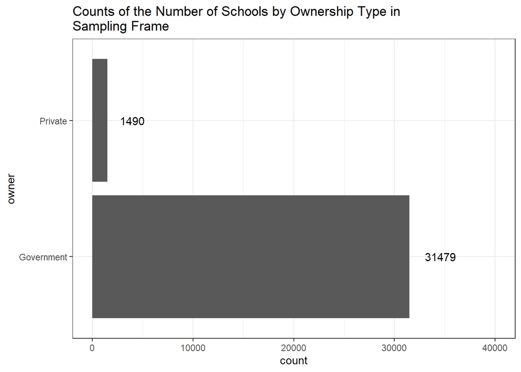

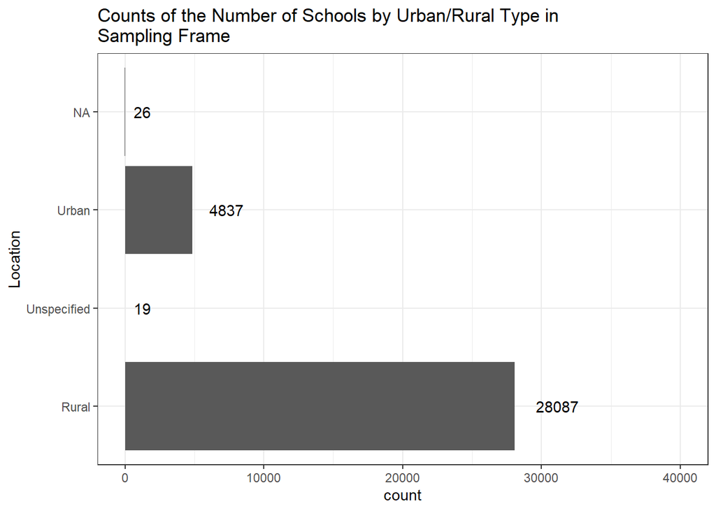

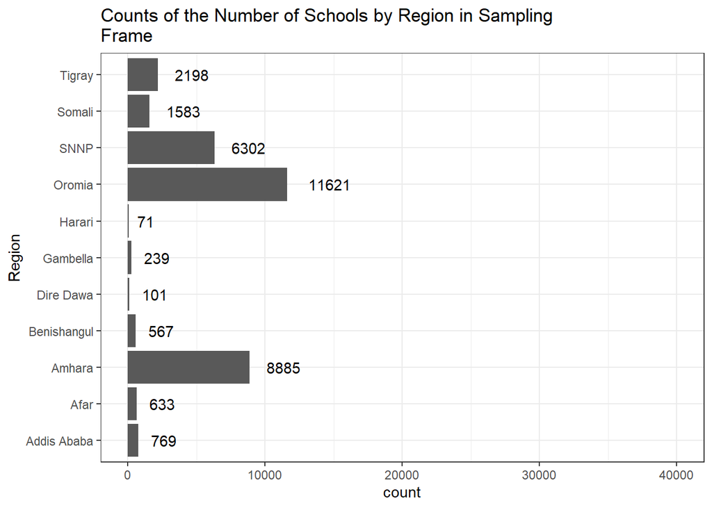

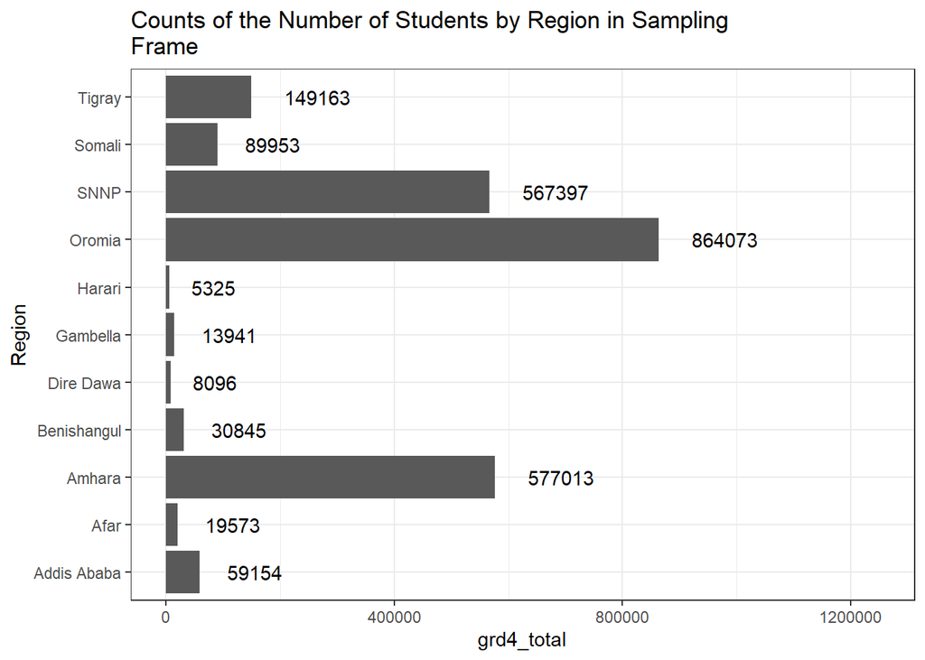

# Sampling of Schools in Woredas

Schools will be selected using stratified, cluster random sampling. The sample is stratified by Region and the urban/rural status of the school. 100 Woredas will be selected at random with probability proportional to the 4th grade student population of the Woreda. Once the Woredas are chosen a sample of 3 schools in each Woreda will be selected, with two of those schools rural and one urban.

|  | Region | Woreda | sampled_woreda |
| --- | --- | --- | --- |
| 1 | Addis Ababa | 06 | Sampled Woreda |
| 2 | Addis Ababa | 13 | Sampled Woreda |
| 3 | Afar | Abala | Sampled Woreda |
| 4 | Afar | Dalifage | Sampled Woreda |
| 5 | Afar | semera Logiya | Sampled Woreda |
| 6 | Amhara | Bati Zuria | Sampled Woreda |
| 7 | Amhara | Dahna | Sampled Woreda |
| 8 | Amhara | Debre Elias | Sampled Woreda |
| 9 | Amhara | Fogera | Sampled Woreda |
| 10 | Amhara | Gidan | Sampled Woreda |

[output cut: 90 more lines]

The list above shows the 100 Woredas selected for our sample. Next, we will choose the 3 schools per Woreda using random selection. Where possible, we will randomly select 2 rural and 1 urban school. In cases where there are insufficient numbers of urban or rural schools, we will drop this condition and select randomly.

|  | Region | Zone | Woreda | School_Name | Sector | owner | Location | Program | Admin_Code | Code_School | Grade | grd4_male | grd4_female | grd1_male | grd1_female | grd4_total | grd1_total | sample | sampled_woreda |
| --- | --- | --- | --- | --- | --- | --- | --- | --- | --- | --- | --- | --- | --- | --- | --- | --- | --- | --- | --- |
| 1 | Addis Ababa | Kolfe-Keranio | 06 | Beteseb | Primary | Private | Urban | 1 | S1007060132 | 601592 | Grade 4 | 44 | 50 | 46 | 52 | 94 | 98 | Sampled School |  |
| 2 | Addis Ababa | Akaki-Kaliti | 06 | Ewiket Wegagen | Primary | Government | Urban | 1 | S1002060152 | 601564 | Grade 4 | 18 | 26 | 30 | 34 | 44 | 64 | Sampled School |  |
| 3 | Addis Ababa | Yeka | 06 | Ethiopia Andinet | Primary | Government | Urban | 1 | S1010060152 | 601254 | Grade 4 | 70 | 65 | 50 | 59 | 135 | 109 | Sampled School |  |
| 4 | Addis Ababa | Yeka | 13 | Merafe Acadame &amp; Primery Schoo | Primary | Private | Rural | 1 | S1010130552 | 695750 | Grade 4 | 38 | 45 | 71 | 67 | 83 | 138 | Sampled School |  |
| 5 | Addis Ababa | Kolfe-Keranio | 13 | Mikililand | Primary | Government | Urban | 1 | S1007130212 | 601618 | Grade 4 | 61 | 57 | 35 | 55 | 118 | 90 | Sampled School |  |
| 6 | Addis Ababa | Bole | 13 | Bole Community | Primary | Government | Urban | 2 | S1004130202 | 601499 | Grade 4 | 23 | 13 | 44 | 52 | 36 | 96 | Sampled School |  |
| 7 | Afar | Two | Abala | Asengola | Primary | Government | Rural | 1 | S0202010652 | 51878 | Grade 4 | 11 | 3 | 10 | 8 | 14 | 18 | Sampled School |  |
| 8 | Afar | Two | Abala | Geris 1st.level school | Primary | Government | Rural | 1 | S0202010642 | 51877 | Grade 4 | 7 | 4 | 7 | 13 | 11 | 20 | Sampled School |  |
| 9 | Afar | Two | Abala | Abala No 2 | Primary | Government | Urban | 1 | S0202010012 | 50003 | Grade 4 | 48 | 63 | 64 | 57 | 111 | 121 | Sampled School |  |
| 10 | Afar | Five | Dalifage | Brakala | Primary | Government | Rural | 1 | S0205010102 | 50681 | Grade 4 | 5 | 5 | 17 | 15 | 10 | 32 | Sampled School |  |

[output cut: 290 more lines]

# Replacement Schools